# Part II - (Interactions between duration and features of trips taken.)

## by (Abdullahi Abogun)

## Investigation Overview

In this investigation, i set out to see which features mostly interacted with the duration of trips. The primary focus were the time(from which i was able to extract day of week and time of day),user type,birth year(from which i was able to create an age column) and station.

## Dataset Overview

The data set includes information about individual rides made in a bike-sharing system covering the greater San Francisco Bay area. It contains anonymized data of users for an approximate 183,000 trips, inluding duration and other attributes. Missing age were replaced with the mean age and no row or column was dropped.

## (Visualization 1)

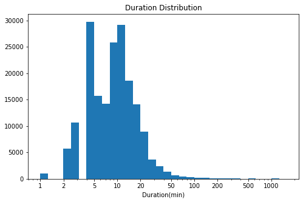

## Disribution of trips across days of week and time of day

Majority of trips are taken during weekdays with Thursday seemingly the busiest day of the week and afternoon being the busiest time of the day.

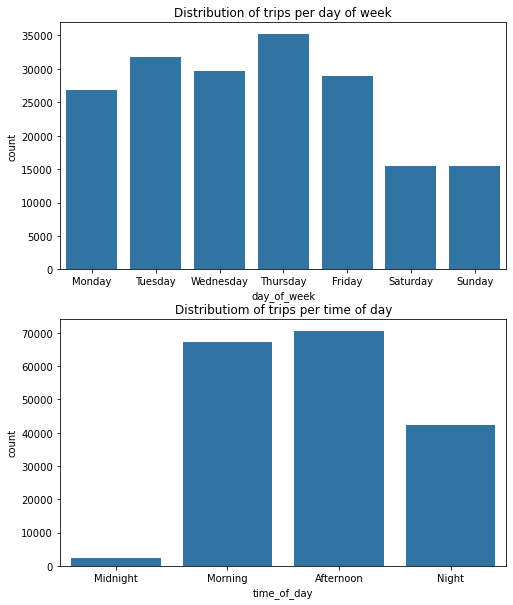

## Duration by Day of week and time of day

We would see that riders spend more time on trips on weekend than they do on weekdays.

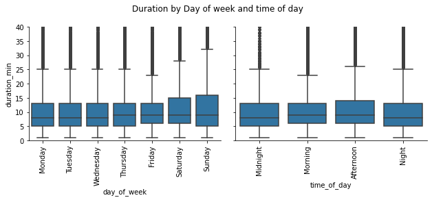

## Duration by Top 20 and Bottom 20 stations.

Generally the top 20 seem to have more rides within the average duration while the bottom 20 seem to slighlty differ

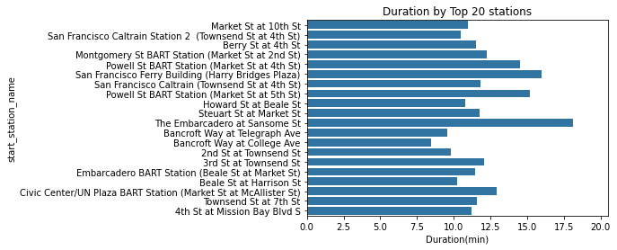

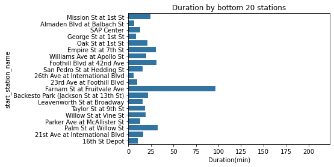

## Duration by Day of the week and User type and by age distribution

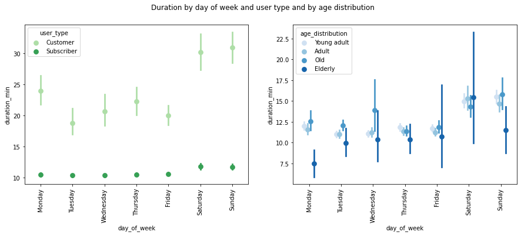